## Lecture 11 : Fixed Income

# Zero Coupon Bonds

- Consider a *risk-free* **zero-coupon** bond
- Face value (final payoff) of $F$ with a maturity of $T$ years
- If the interest rate for maturity $T$ is $r_{T}$, then the current price of this bond is:

$$P_{0} = \frac{F}{(1+r_{T})^{T}}$$

# Yield Curve

- Notation $r_{T}$ implies variation in $r$ over time
- **Yield curve** plots the term structure:

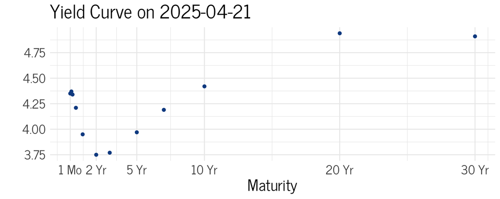

- In theory, produced from zero-coupon bonds or stripped Treasuries

# Yield Curve

- Notation $r_{T}$ implies variation in $r$ over time
- **Yield curve** plots the term structure:

[figure not shown]

- In theory, produced from zero-coupon bonds or stripped Treasuries

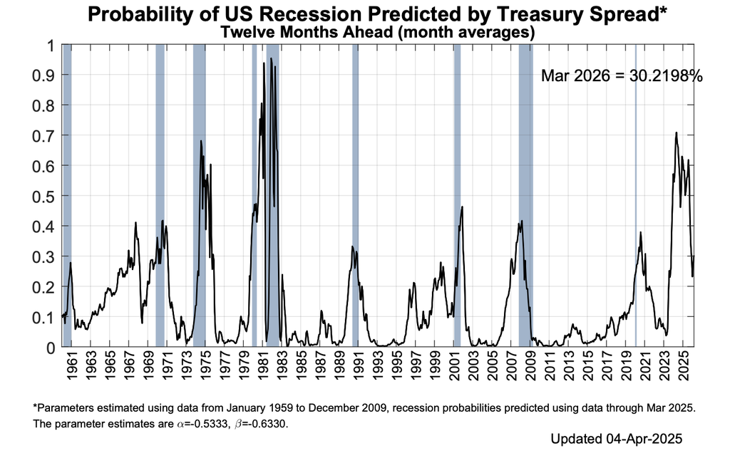

# Coupon Bonds

- Coupon bonds pay coupon C in intervening periods (assume annually)

$$P_{0} = \sum_{t=1}^{T} \frac{C}{(1+r_{t})^{t}} +
\frac{F}{(1+r_{T})^{T}},$$

- $C$ : interest or coupon payments
- $T$ : number of periods (years, here) to maturity
- $r_{t}$ : prevailing discount rate for horizon $t$

# Yield to Maturity

- Suppose we observe coupon $C$, face value $F$ and and price $P$ of a single bond.
- Yield-to-maturity (YTM) solves for the discount rate that makes this price “right”:

$$P = \sum_{t=1}^{T} \frac{C}{(1+YTM)^{t}} + \frac{F}{(1+YTM)^{T}},$$

- YTM is a weighted average of $r_{1}$ through $r_{T}$
- Plots of YTM by horizon approximate the true zero coupon yield curve

# Yield to Maturity – Example

- Consider 10 year bond with face value of 100 and coupon payments of 5 dollars per year
- If these bonds trade below their par value, this implies YTM exceeds coupon rate

$$92.64 = \sum_{t=1}^{10} \frac{5}{(1+0.06)^{t}} +
\frac{100}{(1+0.06)^{10}},$$

- If bond trades at a premium, then coupon rate is higher than the discount rate:

$$108.11 = \sum_{t=1}^{10} \frac{5}{(1+0.04)^{t}} +
\frac{100}{(1+0.04)^{10}},$$

# Coupon Bonds and Yield Curves

- Note, YTM collapses $r_{1}$ through $r_{T}$ to a singular discount rate
- Suppose we want to solve for entire yield curve
- If we want to know $T$ interest rates over the yield curve, we need $T$ bonds (roughly)
  - T equations and T unknowns
- Once we have interest rates for entire yield curve, can price any risk free bond

# Coupon Bonds and Yield Curves

Example:

- Use three bonds to solve for $r_{1}$, $r_{2}$, and $r_{3}$

$$P_{1} = \frac{C_{1} + 100}{(1+r_{1})}\\
P_{2} = \frac{C_{2}}{(1+r_{1})} + \frac{C_{2} + 100}{(1+r_{2})^2}\\
P_{3} = \frac{C_{3} }{(1+r_{1})} +\frac{C_{3} }{(1+r_{2})^2} +
\frac{C_{3} + 100}{(1+r_{3})^3}$$

# Forward Rates

- Consider a contract in which we agree to lend money for 1 year, beginning 1 year in the future (repayment 2 years in the future)
  - $f_{1,2}$ is the *forward* rate for a 1 year loan issued 1 year from today
- Generally, we will call $f_{j,k}$ the forward rate which applies from period $j$ to $k$
  - $f_{0,1}$ is the normal 1 year spot rate, $r_{1}$
- A comment on notation: we use $r_{3}$ to mean today’s prevailing interest rate for a 3-year horizon. This is different from BKM (in which $r_{3}$ refers to the 1-year rate which will prevail three years from now)

# Forward Rates

- Now consider two *equivalent* strategies:
1. Buy $1 worth of a two-year zero coupon bond
   - Receive $(1+r_{2})^{2}$
2. Buy $1 worth of a one-year zero coupon bond and a forward contract for 1 year beginning 1 year in the future
   - Receive $(1+r_{1})(1+f_{1,2})$
- By no arbitrage, since the bonds and contracts are riskless,

$$(1+r_{1})(1+f_{1,2}) = (1+r_{2})^{2}$$

- This implies that the 1- and 2-year bond rates set the forward rate:

$$f_{1,2} = \frac{(1+r_{2})^{2}}{(1+r_{1})} - 1$$

# Forward Rates

- We can extend this to the general case, solving for the forward rate from $t$ to $T$:

$$(1+r_{T})^{T} = (1+r_{t})^{t}(1+f_{t,T})^{T-t}\\
f_{t,T} =
\left[\frac{(1+r_{T})^{T}}{(1+r_{t})^{t}}\right]^{\frac{1}{T-t}} - 1$$

For example, $r_{1} = 5\%$, $r_{2} = 6\%$:

$$f_{1,2} = \left[\frac{(1.06)^{2}}{(1.05}\right] - 1 = 7.01\%$$

# Forward Rates and Term Structure

- Suppose investors are risk-neutral (or the future is certain)
- Then, forward rates should be equal to the expectations of interest rates (why? - what trade could you do if not?)
  - $f_{1,2} = E(r_{1,2})$
  - $f_{2,3} = E(r_{2,3})$
- Hence, long-term rates will represent a geometric average of current and future expected short rates

$$(1+r_{2})^{2} = (1+r_{0,1})(1+f_{1,2}) = (1+r_{0,1})E(1+r_{1,2})$$

# Forward Rates and Term Structure

- Now what if the investor is **risk-averse** and investing over two periods
- Faces a choice between a *sure* two period rate, or a roll-over of a short-term bond
- Recall that a risk-averse investor prefers a sure thing if the expected returns are equal
- In equilibrium, two period investors bid down the long-term rate:

$$(1+r_{2})^{2} = (1+r_{0,1})(1+f_{1,2}) < (1+r_{0,1})E(1+r_{1,2})$$

# Forward Rates and Term Structure

- More commonly, we consider **risk-averse** *one-period* investor (needs liquidity at t=1)
- Face a similar choice: a *sure* one-period rate, or a two-period bond that they sell in period 1
  1. Buy 1-year bond: $(1+r_{1})$
  2. Buy 2-year bond and sell at period 1 at price of $(1+r_{2})^{2}/(1+E(r_{1,2}))$
     - Risky position is now flipped
- Recall that a risk-averse investor prefers a sure thing if the expected returns are equal
- In equilibrium, one-period investors bid down the short-term rate:

$$(1+r_{2})^{2} = (1+r_{0,1})(1+f_{1,2}) > (1+r_{0,1})E(1+r_{1,2})$$

# Interpreting yield curves

- Commonly,upward sloping yield curves are interpreted as evidence of:
  1. Higher future short rates
  2. Liquidity preference for short-term bonds
- Define the liquidity premium as the difference between the forward rate and the expected future short rate

$$K = (1+ f_{t,t+1}) - E(1+r_{t,t+1})$$

- The larger this is, the more that you pay for “certainty” of next period’s short-rate
- Can generate common yield curve patterns under different expectations and values of K

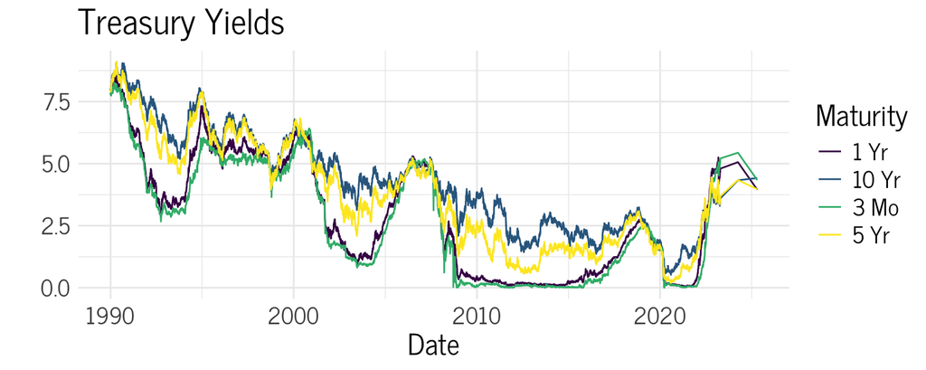

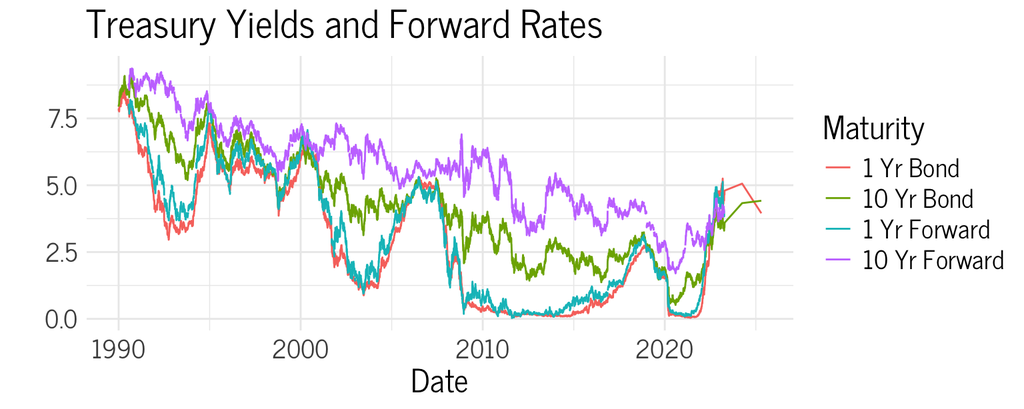

[figure not shown]

# $\Delta$ Bond Price and $\Delta$ Yield to Maturity

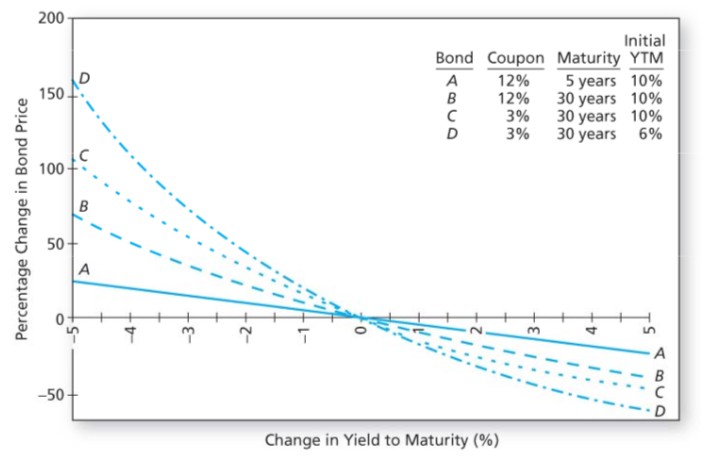

# Bond Pricing Relationships

1. Bond prices and yields are inversely related.
2. Long‐term bonds tend to be more price sensitive than short‐term bonds.
3. Price sensitivity is inversely related to the bond’s coupon rate.
4. Price sensitivity is inversely related to the yield to maturity at which the bond is selling.
5. An increase in a bond’s yield to maturity results in a smaller price change than a decrease of equal magnitude.

# Duration

- Need a single measure that tells us the interest rate sensitivity of a bond/portfolio
- Duration is a measure of the effective maturity
- The weighted average of the amount of time until each payment is received, with the weights proportional to the present value of the payment
- Duration is shorter than maturity for all bonds except zero coupon bonds
- Duration is equal to maturity for zero coupon bonds

# Duration: Calculation

- Define duration as follows:

$$D = \sum_{t=1}^{T} t \times w_{t} \\
w_{t} = \left[\frac{CF_{t}}{(1+YTM)^{t}}\right] / P,$$

where YTM is the yield to maturity, $P$ is the price, and $CF_{t}$ is the cashflows at time $t$

- Can show that

$$\frac{\Delta P}{P} = -D\frac{\Delta (1+YTM)}{(1+YTM)}.$$

# Modified Duration

- Alternatively, *modified* duration ($D^{*}$) divides duration by $(1+YTM)$ such that

$$\frac{\Delta P}{P} = -D^{*} \Delta YTM$$

# Duration Matching

- Often, duration is important for investors who want to “immunize”” themselves from interest rate exposure
- Consider a pension fund with 30 years worth of obligations to an individual
  - Modified duration of liabilities is $\sim$ 9.9 years with a YTM of 7.75%
  - Reflects the weighted average maturity of their obligations
- Note, a 1% decrease in interest rates will increase the value of liabilities by 9.9%
  - Why?

# Duration Matching

# Caveats

# Application

- Consider the case of Orange County, 1994
- Bob Citron managed county funds as a large bet on interest rates
- Borrowed large amounts in short term markets and reinvested in 5 year notes
- Via leverage, portfolio had an effective duration of 7.4 years (2.74 duration of assets $\times$ 2.7 leverage)

# Orange County

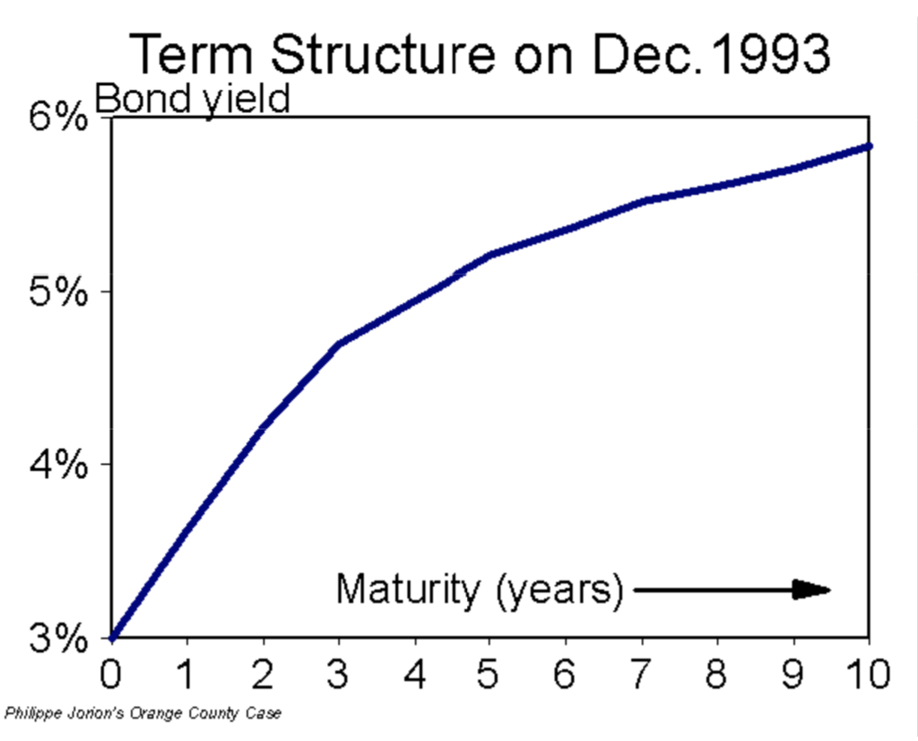

# Orange County

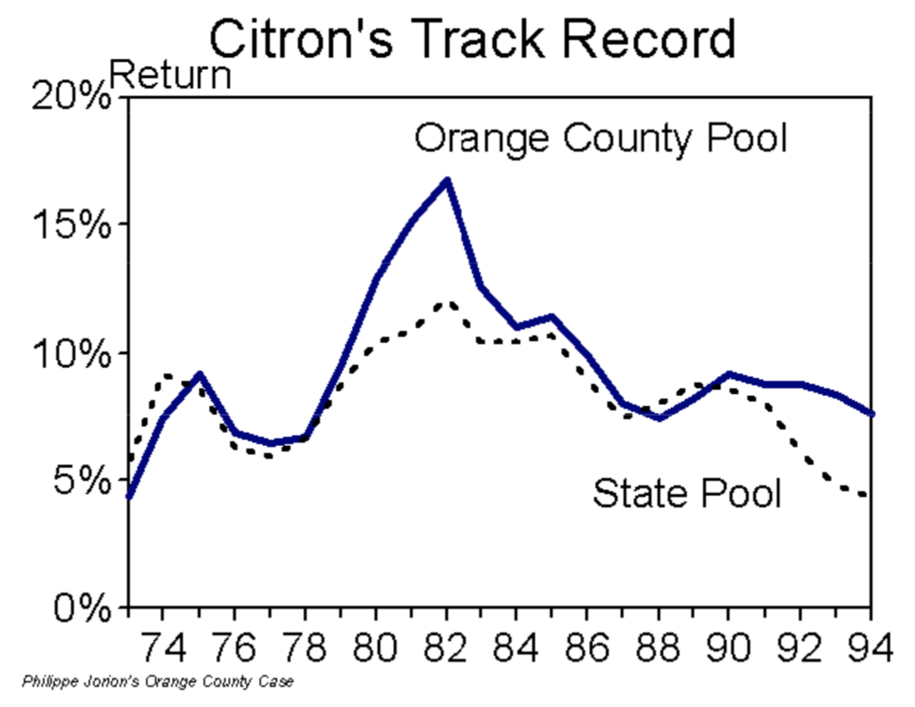

# Orange County

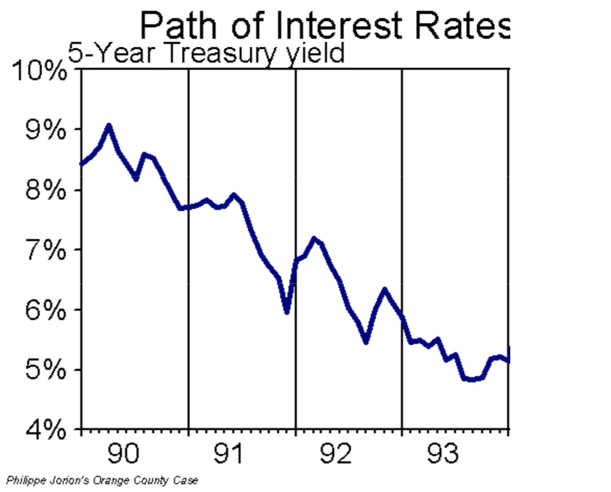

# Orange County

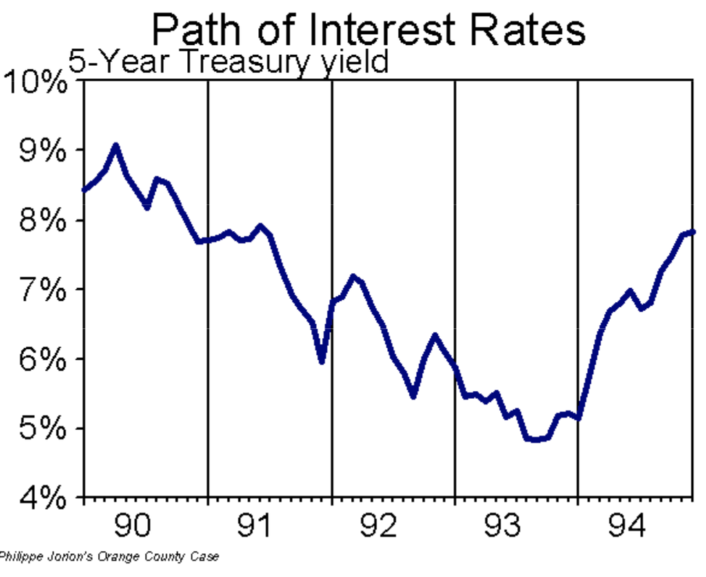

# Orange County Application

- Four consecutive rate hikes by the FOMC
- The OC has a $1.6 billion loss on a $7.5 billion portfolio (before leverage), declares bankruptcy
- Question: How does this 1.6BN loss compare to expectations?
- A useful application of VaR and duration

# Interest Rate Swaps

- Fixed v. floating interest rate swap
- One party pays a floating interest rate X notional value
- Other party pays a fixed interest rate (the swap rate) X notional value
- Exchanges made periodically over a fixed term
- Fixed interest rate is set so that no cash exchanges hands at initiation
- Swaps provide synthetic immunization

# Interest Rate Swaps: Example

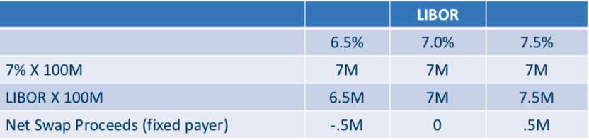

- Note, counterparty which pays fixed and receives floating is short (bonds)
- Combining along bond portfolio with a short swap position is a means toward immunization
  - e.g. add swap proceeds to a 7% coupon and you have a floating rate note

# Pricing Swaps

- Consider the following three period fixed vs. floating rate swap
- Lending or borrowing at forward rates can be achieved synthetically, or in futures market
- Consider cash flows from a hedged counterparty who received fixed and pays floating

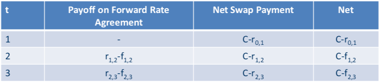

# Pricing Swaps

- C is set to make the net present value of these streams equal to zero
- This is known as the swap rate and is a weighted average of the spot and forward rates

$$0 = \frac{C- r_{0,1}}{(1+r_{1})} + \frac{C- f_{1,2}}{(1+r_{2})^{2}} +
\frac{C- f_{2,3}}{(1+r_{3})^{3}}$$